# Assignment_3_6783

```python
%%html
<style>
table {float:left}
</style>
```

### Group Members:

[output not shown]

#### Part I: Optimal span for LOESS

Write your own function to employ LOO-CV and GCV in selecting the optimal span for LOESS. Definitions of LOO-CV and GCV can be found on page 33 of [lec_W5_NonlinearRegression.pdf] Below, we’ll use CV to refer to LOO-CV.

   Determine the best span value based on the CV and GCV results. For this dataset, both methods recommend the same span.

```python
import numpy as np
import pandas as pd
import matplotlib.pyplot as plt

from sklearn.model_selection import GridSearchCV

from skfda.misc.hat_matrix import NadarayaWatsonHatMatrix
from skfda.ml.regression._kernel_regression import KernelRegression

from skmisc.loess import loess
import warnings
warnings.filterwarnings("ignore")

Coding3_Data = pd.read_csv("https://liangfgithub.github.io/Data/Coding3_Data.csv")
```

```python
df = Coding3_Data
# print(df.head())
# print(df.shape)
```

```python
#LOOCV 是一種交叉驗證方法，適合在樣本數不多的情況下使用，它的原理是每次從訓練集中移除一個樣本，用剩下的樣本進行訓練，再使用移除的樣本進行驗證
#LOOCV 結果的大小基本上反映了模型在未見過的數據上的表現, ex: 隨機的, 不理性的
def compute_LOO_CV(residuals, trace): #
    return np.mean((residuals/(1-trace))**2)


#GCV 是 LOOCV 的一種近似方法，它不需要每次都重建模型，而是利用帽子矩陣的對角線來進行調整，使得結果近似於 LOOCV 的效果，且計算效率更高。
def compute_GCV(residuals, trace):
    avg_trace = np.repeat(np.mean(trace), len(trace))
    return np.mean((residuals/(1-avg_trace))**2)


#對角線元素非常重要，因為它們幫助我們理解模型的偏差和方差之間的平衡
def compute_pred_error(X, y, span): # given: Inputs: x (an n-by-1 feature vector) and span (a numerical value).
    model = loess(df['x'], df['y'], span=span)
    model.fit()
    residuals = model.outputs.fitted_residuals
    trace = model.outputs.diagonal #requirement: Output: n-by-1 vector representing the diagonal of the smoother matrix S.
    return {
        "loocv": compute_LOO_CV(residuals, trace),
        "gcv": compute_GCV(residuals, trace),
    }

spans = np.arange(0.2, 0.9 + 0.05, 0.05)    # Report your CV and GCV for the following 15 span values: 0.20, 0.25, . . . , 0.90.
X = df['x'].to_numpy()
y = df['y'].to_numpy()
pred_errors = []

for span in spans:
    pred_error = compute_pred_error(X, y, span) #compute_pred_error(X, y_fake, span)
    pred_errors.append({"span": span, **pred_error})
    print("span: {span: <10} loocv: {loocv: <25} gcv: {gcv: <25}".format(
        span=f'{span:.2f}',
        **pred_error
    ))


def get_optimal_spans(pred_errors: pd.DataFrame):
    # 將 'loocv' 和 'gcv' 的最小值分別儲存在一個字典中
    optimal_spans = {
        computation: round(pred_errors['span'][pred_errors[computation].idxmin()], 2)
        for computation in ['loocv', 'gcv']
    }
    return optimal_spans


pred_errors = pd.DataFrame(pred_errors)
optimal_spans = get_optimal_spans(pred_errors)
print("loocv optimal span: {}".format(optimal_spans["loocv"]))
print("gcv optimal span: {}".format(optimal_spans["gcv"]))
```

```
span: 0.20       loocv: 12.415910699871809        gcv: 2.110161841942955
span: 0.25       loocv: 2.2414734958901503        gcv: 1.4892056326217187
span: 0.30       loocv: 1.5029798111583694        gcv: 1.1901098446318226
span: 0.35       loocv: 1.2591747084691491        gcv: 1.1744229564766888
span: 0.40       loocv: 1.1903799279913367        gcv: 1.102539903823101
span: 0.45       loocv: 1.1568121230625683        gcv: 1.0625034645069498
span: 0.50       loocv: 1.1256523403714556        gcv: 1.0418328786112796
span: 0.55       loocv: 1.179663752374441         gcv: 1.1188405514998327
span: 0.60       loocv: 1.179464162542817         gcv: 1.1192688072551902
span: 0.65       loocv: 1.2509138273813036        gcv: 1.180584776931384
span: 0.70       loocv: 1.553562264253347         gcv: 1.5190908128135594
span: 0.75       loocv: 1.6361746170729456        gcv: 1.6274293455726156
span: 0.80       loocv: 1.764533626604454         gcv: 1.7445490858435333
span: 0.85       loocv: 1.9760935148587322        gcv: 1.9256959613535605
span: 0.90       loocv: 2.0351079200441444        gcv: 1.9798203978761495
loocv optimal span: 0.5
gcv optimal span: 0.5
```

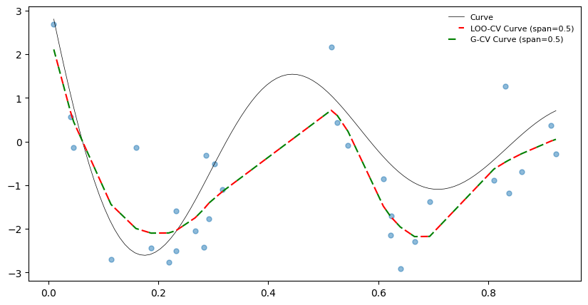

```python
plt.figure(figsize=(10,5))
plt.scatter(df['x'], df['y'], marker='.', s=100, alpha=0.5, c='tab:blue')

true_x = np.linspace(min(df['x']), max(df['x']), 100)
true_y = np.sin(12*(true_x+0.2))/(true_x+0.2)
plt.plot(true_x, true_y, c='black', linewidth=0.5, label='Curve')

for computation, span in optimal_spans.items():

    model = loess(df['x'], df['y'], span=span)
    model.fit()
    pred = model.predict(df['x'])

    if computation == "loocv":
        plt.plot(df['x'], pred.values, linestyle=(5, (5, 7)), color='red', label=f'LOO-CV Curve (span={span})')
    if computation == "gcv":
        plt.plot(df['x'], pred.values, linestyle=(0, (5, 7)), color='green', label=f'G-CV Curve (span={span})')

plt.legend(fontsize=8, markerscale=1.5, edgecolor='white')
```

#### Part II: Ridgeless and double descent

So far in our course, we’ve utilized the U-shaped bias-variance trade-off curve as a pivotal tool for model selection. This has aided us in methodologies such as ridge/lasso regression, tree pruning, and smoothing splines, among others

A key observation is that when a model interpolates training data to the extent that the Residual Sum of Squares (RSS) equals zero, it’s typically a red flag signaling overfitting. Such models are anticipated to perform inadequately when presented with new, unseen data.

However, in modern practice, very rich models such as neural networks are trained to exactly fit  
(i.e., interpolate) the data. Classically, such models would be considered overfitted, and yet they  
often obtain high accuracy on test data. This apparent contradiction has raised questions about  
the mathematical foundations of machine learning and their relevance to practitioners. (Belkin et  
al. 2019)

In this assignment, we will use Ridgeless to illustrate the double descent phenomenon. Our setup is similar to, but not the same as, Section 8 in Hastie (2020). Data Remember the dataset used in Coding 2 Part I? It consisted of 506 rows (i.e., n = 506) and 14 columns: Y , X1 through X13. Based on this dataset, we have formed Coding3_dataH.csv, which is structured as follows: • It contains 506 rows, corresponding to n = 506. • There are 241 columns in total. The first column represents Y . The subsequent 240 columns relate to the NCS basis functions for each of the 13 X variables. The number of knots are individually determined for each feature.

#### Task 1: Ridgeless Function

Your task is to write a function ridgeless to implement Ridgeless Least Squares, which is equivalent to Principal Component Regression (PCR) using all principal components, with the option scale = FALSE. This means that when computing the principal components (PCs), you center each column of the design matrix without scaling.

- Input: Train and test datasets. In both datasets, the first column represents the response vector Y, and the remaining columns represent the features X.
- Output: Training and test errors, where the error refers to the average squared error.
- You are allowed to use R/Python packages or built-in functions for PCA/SVD, but you are not permitted to use packages or functions specifically designed for linear regression, PCR, or ridge regression.
- Additionally, you are not allowed to perform matrix inversion in your code. After performing PCA/SVD, the resulting design matrix will have orthogonal columns. This allows you to compute the least squares coefficients through simple matrix multiplication, avoiding the need for matrix inversion.
- For numerical stability, you should exclude directions with extremely small eigenvalues (in PCA) or singular values (in SVD). For example, consider using a threshold of eps = 1e-10 for singular values.
- Although training errors aren’t required for our simulation, I recommend including them in the ridgeless output as a helpful debugging tool. Ideally, the training error should match the residual sum of squares (RSS) from a standard linear regression model.

```python
from sklearn.model_selection import train_test_split
from sklearn.decomposition import PCA
from sklearn.metrics import mean_squared_error

Coding3_dataH = pd.read_csv("https://liangfgithub.github.io/F22/Coding3_dataH.csv")
data = Coding3_dataH.to_numpy()
X, y = data[:, 1:], data[:, 0]

def ridgeless(X_train, X_test, y_train, y_test):

    # default behavior of sklearn.decomposition.PCA is to center each column
    # of the design matrix from the training data without scaling
    pca = PCA().fit(X_train)
    F_train = pca.transform(X_train)
    k = sum(pca.singular_values_ > 1e-10)

    F_train = F_train[:, :k]
    F_test = pca.transform(X_test)[:, :k]

    B = y_train.T @ F_train / np.sum(F_train**2, axis=0)
    intercept = np.mean(y_train)

    train_mse = mean_squared_error(y_train, F_train.dot(B) + intercept)
    test_mse = mean_squared_error(y_test, F_test.dot(B) + intercept)
    return {"train_mse": train_mse, "test_mse": test_mse}

X_train, X_test, y_train, y_test = train_test_split(
    X, y, test_size=0.75, random_state=7607
)

print(ridgeless(X_train, X_test, y_train, y_test))
```

```
{'train_mse': 4.719286018474787e-28, 'test_mse': 0.09633235668696717}
```

```python
from skmisc.loess import loess
from scipy.interpolate import splev, interp1d
from sklearn.linear_model import LinearRegression

from numpy.linalg import inv
from sklearn.cluster import KMeans
from sklearn.decomposition import PCA
from sklearn.metrics import mean_squared_error
from sklearn.model_selection import train_test_split

test_errors = np.empty([30, 236], dtype=float) # 7080 simulations
print(test_errors.shape)
for i in range(30): #30
    for d in range(5, 241): #241
        X_train, X_test, y_train, y_test = train_test_split(
            X[:, :d], y, test_size=0.75, random_state=7607
        )
        test_error = ridgeless(X_train, X_test, y_train, y_test)
        test_errors[i, d-5] = test_error["test_mse"]
        # print(f"Iteration {i+1}, d={d}, test error: {test_error['test_mse']}")
```

```
(30, 236)
```

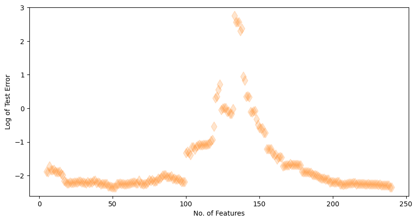

```python
plt.figure(figsize=(10,5))
x, y = range(5, 241), np.log(np.median(test_errors, axis=0))
plt.scatter(x, y, marker='d', s=100, linewidth=1, alpha=0.2, c='tab:orange')
# plt.plot(range(5, 241), np.log(np.median(test_errors, axis=0)))
plt.xlabel("No. of Features")
plt.ylabel("Log of Test Error")
plt.show()
```

```python
Sales_Transactions_Dataset_Weekly = pd.read_csv("https://liangfgithub.github.io/Data/Sales_Transactions_Dataset_Weekly.csv")
df = Sales_Transactions_Dataset_Weekly
df = df.iloc[:, 1:52]   # {W0, W1, ..., W51}

# Apply mean centering to each row
df = df.apply(lambda x: x-x.mean(), axis=1)
```

```python
def ns(x, df=None, knots=None, boundary_knots=None, include_intercept=False):
    degree = 3

    if boundary_knots is None:
        boundary_knots = [np.min(x), np.max(x)]
    else:
        boundary_knots = np.sort(boundary_knots).tolist()

    oleft = x < boundary_knots[0]
    oright = x > boundary_knots[1]
    outside = oleft | oright
    inside = ~outside

    if df is not None:
        nIknots = df - 1 - include_intercept
        if nIknots < 0:
            nIknots = 0

        if nIknots > 0:
            knots = np.linspace(0, 1, num=nIknots + 2)[1:-1]
            knots = np.quantile(x[~outside], knots)

    Aknots = np.sort(np.concatenate((boundary_knots * 4, knots)))
    n_bases = len(Aknots) - (degree + 1)

    if any(outside):
        basis = np.empty((x.shape[0], n_bases), dtype=float)
        e = 1 / 4 # in theory anything in (0, 1); was (implicitly) 0 in R <= 3.2.2

        if any(oleft):
            k_pivot = boundary_knots[0]
            xl = x[oleft] - k_pivot
            xl = np.c_[np.ones(xl.shape[0]), xl]

            # equivalent to splineDesign(Aknots, rep(k.pivot, ord), ord, derivs)
            tt = np.empty((xl.shape[1], n_bases), dtype=float)
            for j in range(xl.shape[1]):
                for i in range(n_bases):
                    coefs = np.zeros((n_bases,))
                    coefs[i] = 1
                    tt[j, i] = splev(k_pivot, (Aknots, coefs, degree), der=j)

            basis[oleft, :] = xl @ tt

        if any(oright):
            k_pivot = boundary_knots[1]
            xr = x[oright] - k_pivot
            xr = np.c_[np.ones(xr.shape[0]), xr]

            tt = np.empty((xr.shape[1], n_bases), dtype=float)
            for j in range(xr.shape[1]):
                for i in range(n_bases):
                    coefs = np.zeros((n_bases,))
                    coefs[i] = 1
                    tt[j, i] = splev(k_pivot, (Aknots, coefs, degree), der=j)

            basis[oright, :] = xr @ tt

        if any(inside):
            xi = x[inside]
            tt = np.empty((len(xi), n_bases), dtype=float)
            for i in range(n_bases):
                coefs = np.zeros((n_bases,))
                coefs[i] = 1
                tt[:, i] = splev(xi, (Aknots, coefs, degree))

            basis[inside, :] = tt
    else:
        basis = np.empty((x.shape[0], n_bases), dtype=float)
        for i in range(n_bases):
            coefs = np.zeros((n_bases,))
            coefs[i] = 1
            basis[:, i] = splev(x, (Aknots, coefs, degree))

    const = np.empty((2, n_bases), dtype=float)
    for i in range(n_bases):
        coefs = np.zeros((n_bases,))
        coefs[i] = 1
        const[:, i] = splev(boundary_knots, (Aknots, coefs, degree), der=2)

    if include_intercept is False:
        basis = basis[:, 1:]
        const = const[:, 1:]

    qr_const = np.linalg.qr(const.T, mode='complete')[0]
    basis = (qr_const.T @ basis.T).T[:, 2:]

    return basis
```

```python
week_idx = np.arange(1, 51 + 1, 1)  # {1, 2, ... 52}
F = ns(week_idx, df=9)

X = df.to_numpy()
print(X.shape)

B = inv(np.dot(F.T, F)).dot(F.T).dot(X.T).T
print(B.shape)
print(B[0])
```

```
(811, 51)
(811, 9)
[ 4.11937464 -1.8923393  -1.04711408 -1.70153946 -0.78273742  2.5723075
 -3.58110525 -0.21231445 -6.01306025]
```

```python
def get_cluster(data, kmeans, label: int):
    cluster_idx = (kmeans.labels_ == label).astype(int)
    cluster_arrays = data[cluster_idx.astype(bool)]
    cluster_center = kmeans.cluster_centers_[label]
    print(f"Cluster {label}: {(sum(cluster_idx), len(cluster_arrays))}")
    return cluster_arrays, cluster_center
```

```
Cluster 0: (144, 144)
Cluster 1: (53, 53)
Cluster 2: (506, 506)
Cluster 3: (38, 38)
Cluster 4: (40, 40)
Cluster 5: (30, 30)
```

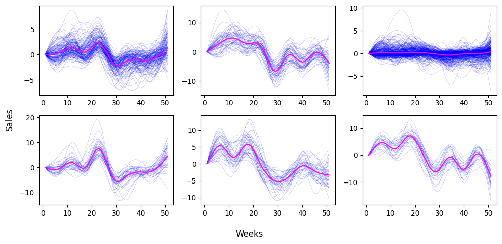

```python
kmeans = KMeans(n_clusters=6, random_state=7607, n_init="auto").fit(B) # B

fig, axes = plt.subplots(nrows=2, ncols=3)
plot_lookup = {
    0: axes[0][0], 1: axes[0][1], 2: axes[0][2],
    3: axes[1][0], 4: axes[1][1], 5: axes[1][2],
}

for cluster in range(6):
    subplot = plot_lookup[cluster]
    cluster_coefficients, cluster_center = get_cluster(B, kmeans, cluster)
    for coefficients in cluster_coefficients:
        subplot.plot(week_idx, F.dot(coefficients), color='blue', alpha=0.3, linewidth=0.4)
    subplot.plot(week_idx, F.dot(cluster_center), color='fuchsia', linewidth=1.5)

fig.supxlabel("Weeks")
fig.supylabel("Sales")
fig.set_figwidth(10)
fig.tight_layout()
```

```
Cluster 0: (104, 104)
Cluster 1: (40, 40)
Cluster 2: (580, 580)
Cluster 3: (47, 47)
Cluster 4: (36, 36)
Cluster 5: (4, 4)
```

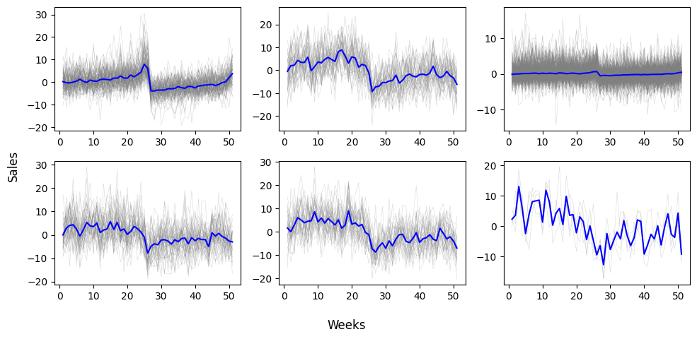

```python
kmeans = KMeans(n_clusters=6, random_state=7607, n_init="auto").fit(X) # X

fig, axes = plt.subplots(nrows=2, ncols=3)
plot_lookup = {
    0: axes[0][0], 1: axes[0][1], 2: axes[0][2],
    3: axes[1][0], 4: axes[1][1], 5: axes[1][2],
}

for cluster in range(6):
    subplot = plot_lookup[cluster]
    cluster_sales, cluster_center = get_cluster(X, kmeans, cluster)
    for sales in cluster_sales:
        subplot.plot(week_idx, sales, color='gray', alpha=0.3, linewidth=0.4)
    subplot.plot(week_idx, cluster_center, color='blue', linewidth=1.5)

fig.supxlabel("Weeks")
fig.supylabel("Sales")
fig.set_figwidth(10)
fig.tight_layout()
```